# Gene effect: filtered out IN/DELs, no MSK

Libraries

```r
library(tidyverse)
library(data.table)
library(ggbeeswarm)
library(readr)
library(ggpubr)


select = dplyr::select
rename = dplyr::rename
```

source R profile. Memory was set to 500000.

```r
Sys.setenv("R_ENVIRON_USER"='/Users/castilln/.Renviron')
Sys.getenv("R_ENVIRON_USER")
```

```
[1] "/Users/castilln/.Renviron"
```

Set wd

Load data

```r
#DEPMAP somatic mutations
ccle = fread("depmap/ccle_info_21q1.csv")
```

```
|--------------------------------------------------|
|==================================================|
|--------------------------------------------------|
|==================================================|
```

```r
ccle =
  ccle %>%
  rename("SYMBOL" = "Hugo_Symbol")

#CRISPR gene effect
gene_effect = fread("depmap/achilles/Achilles_gene_effect.csv")

#LOAD ACTIONABLE SPLICE OUTPUT (ALREADY FILTERED FOR MSK)
splice_genes = readRDS("spliceai/spliceAI05_Annotated.rds")
head(actionable_splice)
```

```
Error in head(actionable_splice) : object 'actionable_splice' not found
```

```r
list_spliced_genes =
  splice_genes %>%
  select(SYMBOL) %>%
  distinct() %>%
  pull()

head(list_spliced_genes)
```

```
[1] "PGBD2"   "ZNF692"  "SH3BP5L" "OR2T3"   "OR14C36" "OR2T12"
```

Select variables of interest from ccle and filter out MSK IMPACT genes

```r
df_mutation_meta =
  ccle %>%
  select(DepMap_ID, SYMBOL, primary_disease, Variant_Type, isDeleterious) %>%
  filter(SYMBOL %in% list_spliced_genes)
head(df_mutation_meta)
```

| DepMap_ID | SYMBOL | primary_disease | Variant_Type | isDeleterious |
| --- | --- | --- | --- | --- |
| ACH-000001 | VPS13D | Ovarian Cancer | SNP | TRUE |
| ACH-000001 | IFNLR1 | Ovarian Cancer | SNP | FALSE |
| ACH-000001 | TMEM57 | Ovarian Cancer | INS | TRUE |
| ACH-000001 | ZSCAN20 | Ovarian Cancer | SNP | FALSE |
| ACH-000001 | MAST2 | Ovarian Cancer | SNP | FALSE |
| ACH-000001 | GBP4 | Ovarian Cancer | SNP | FALSE |

Create new column with custom isDeleterious information. isDeleterious only if mutation is an insertion or deletion

```r
df_mutation_delet =
  df_mutation_meta %>%
  mutate(isDel = ifelse(Variant_Type == "SNP", FALSE, TRUE)) %>%
  select(-isDeleterious)

dim(df_mutation_delet)
```

```
[1] 888994      5
```

```r
head(df_mutation_delet)
```

| DepMap_ID | SYMBOL | primary_disease | Variant_Type | isDel |
| --- | --- | --- | --- | --- |
| ACH-000001 | VPS13D | Ovarian Cancer | SNP | FALSE |
| ACH-000001 | IFNLR1 | Ovarian Cancer | SNP | FALSE |
| ACH-000001 | TMEM57 | Ovarian Cancer | INS | TRUE |
| ACH-000001 | ZSCAN20 | Ovarian Cancer | SNP | FALSE |
| ACH-000001 | MAST2 | Ovarian Cancer | SNP | FALSE |
| ACH-000001 | GBP4 | Ovarian Cancer | SNP | FALSE |

```r
##PIVOT LONG EFFECT MATRIX
df_crispr =
  gene_effect %>%
  pivot_longer(cols = -DepMap_ID, names_to = "SYMBOL", values_to = "gene_effect") %>%
  mutate(SYMBOL = gsub(" .*","",SYMBOL)) %>%
  filter(SYMBOL %in% list_spliced_genes)

head(df_crispr)
```

| DepMap_ID | SYMBOL | gene_effect |
| --- | --- | --- |
| ACH-000004 | A1BG | 0.18133191 |
| ACH-000004 | A2M | -0.19386736 |
| ACH-000004 | A2ML1 | -0.02458734 |
| ACH-000004 | AACS | 0.29258221 |
| ACH-000004 | AADAC | 0.16748214 |
| ACH-000004 | AADACL2 | 0.03155600 |

```r
dim(df_crispr)
```

```
[1] 8053336       3
```

Add splice variant annotation to spliceAI output data frame Since this data has already been filtered for SNPs producing a splice variant with >0.5 confidence, as predicted by the NN, we can simply tag all SNPs as TRUE

```r
df_splice =
  splice_genes %>%
  mutate(splice_variant = TRUE,
         splice_gene = SYMBOL) %>%
  select(DepMap_ID,SYMBOL,primary_disease,splice_variant,splice_gene,MAX_PROBABILITY, exon_intron)

head(df_splice)
```

|  | DepMap_ID | SYMBOL | primary_disease | splice_variant | splice_gene | MAX_PROBABILITY | exon_intron |
| --- | --- | --- | --- | --- | --- | --- | --- |
| 1 | ACH-000996 | PGBD2 | Endometrial/Uterine Cancer | TRUE | PGBD2 | 0.57 | intron |
| 2 | ACH-002129 | ZNF692 | Lung Cancer | TRUE | ZNF692 | 0.89 | intron |
| 3 | ACH-000524 | SH3BP5L | Ovarian Cancer | TRUE | SH3BP5L | 0.65 | intron |
| 4 | ACH-000990 | SH3BP5L | Endometrial/Uterine Cancer | TRUE | SH3BP5L | 0.98 | intron |
| 5 | ACH-002269 | OR2T3 | Brain Cancer | TRUE | OR2T3 | 0.57 | intron |
| 6 | ACH-000310 | OR14C36 | Neuroblastoma | TRUE | OR14C36 | 0.52 | intron |

```r
dim(df_splice)
```

```
[1] 28982     7
```

Filter out SNPs without cell line annotation (this is due to different versions of CCLE data being used)

```r
df_splice =
  df_splice %>%
  filter(!is.na(DepMap_ID))
dim(df_splice)
```

```
[1] 28978     7
```

Create new column with custom isDeleterious information. isDeleterious only if mutation is an insertion or deletion

```r
df_mutation_delet =
  df_mutation_meta %>%
  mutate(isDel = ifelse(Variant_Type == "SNP", FALSE, TRUE)) %>%
  select(-isDeleterious)

dim(df_mutation_delet)
```

```
[1] 888994      5
```

```r
head(df_mutation_delet)
```

| DepMap_ID | SYMBOL | primary_disease | Variant_Type | isDel |
| --- | --- | --- | --- | --- |
| ACH-000001 | VPS13D | Ovarian Cancer | SNP | FALSE |
| ACH-000001 | IFNLR1 | Ovarian Cancer | SNP | FALSE |
| ACH-000001 | TMEM57 | Ovarian Cancer | INS | TRUE |
| ACH-000001 | ZSCAN20 | Ovarian Cancer | SNP | FALSE |
| ACH-000001 | MAST2 | Ovarian Cancer | SNP | FALSE |
| ACH-000001 | GBP4 | Ovarian Cancer | SNP | FALSE |

Now, let’s join the spliceAI output with the CCLE mutation annotation information.

```r
df_splice_annot =
  df_splice %>%
  left_join(df_mutation_delet, by = c("SYMBOL", "DepMap_ID", "primary_disease")) %>%
  distinct() %>%
  #indicate those splice variants that occur in a different gene than the one we gave as input
  mutate(off_target = ifelse(is.na(Variant_Type), TRUE, FALSE)) %>%
  #Substitute NAs from Variant_Type with "SNP"
  mutate(Variant_Type = ifelse(is.na(Variant_Type), "SNP", Variant_Type))

df_off_target_nomsk =
  df_splice_annot %>%
  filter(off_target == T) %>%
  select(-c("Variant_Type", "isDel"))

#write_csv(df_off_target_nomsk, "spliceai/off_targe_spliceAIout.csv")

dim(df_splice_annot)
```

```
[1] 29670    10
```

```r
head(df_splice_annot)
```

|  | DepMap_ID | SYMBOL | primary_disease | splice_variant | splice_gene | MAX_PROBABILITY | exon_intron | Variant_Type | isDel | off_target |
| --- | --- | --- | --- | --- | --- | --- | --- | --- | --- | --- |
| 1 | ACH-000996 | PGBD2 | Endometrial/Uterine Cancer | TRUE | PGBD2 | 0.57 | intron | SNP | FALSE | FALSE |
| 2 | ACH-002129 | ZNF692 | Lung Cancer | TRUE | ZNF692 | 0.89 | intron | SNP | FALSE | FALSE |
| 3 | ACH-000524 | SH3BP5L | Ovarian Cancer | TRUE | SH3BP5L | 0.65 | intron | SNP | FALSE | FALSE |
| 4 | ACH-000990 | SH3BP5L | Endometrial/Uterine Cancer | TRUE | SH3BP5L | 0.98 | intron | SNP | FALSE | FALSE |
| 5 | ACH-002269 | OR2T3 | Brain Cancer | TRUE | OR2T3 | 0.57 | intron | SNP | FALSE | FALSE |
| 6 | ACH-000310 | OR14C36 | Neuroblastoma | TRUE | OR14C36 | 0.52 | intron | SNP | FALSE | FALSE |

Let’s process the mutation metadata in order to tag each gene in each cell line if at least one of the variants in that gene is deleterious.

```r
df_mutation_delet_tag =
  df_mutation_delet %>%
  group_by(DepMap_ID, SYMBOL) %>%
  summarise(gene_deleterious = ifelse(sum(isDel) > 0,TRUE,FALSE)) %>%
  ungroup()
head(df_mutation_delet_tag)
```

| DepMap_ID | SYMBOL | gene_deleterious |
| --- | --- | --- |
| ACH-000001 | ABCC4 | FALSE |
| ACH-000001 | ACRC | FALSE |
| ACH-000001 | ACTR3B | FALSE |
| ACH-000001 | ADAM10 | FALSE |
| ACH-000001 | ADCY1 | FALSE |
| ACH-000001 | ALPK2 | TRUE |

```r
dim(df_mutation_delet_tag)
```

```
[1] 698610      3
```

Now we can join the deleterious mutation annotated genes and cell lines with the spliceAI output

```r
df_splice_deleterious =
 df_splice_annot %>%
  left_join(df_mutation_delet_tag, by = c("SYMBOL", "DepMap_ID")) %>%
  distinct()

head(df_splice_deleterious)
```

|  | DepMap_ID | SYMBOL | primary_disease | splice_variant | splice_gene | MAX_PROBABILITY | exon_intron | Variant_Type | isDel | off_target | gene_deleterious |
| --- | --- | --- | --- | --- | --- | --- | --- | --- | --- | --- | --- |
| 1 | ACH-000996 | PGBD2 | Endometrial/Uterine Cancer | TRUE | PGBD2 | 0.57 | intron | SNP | FALSE | FALSE | FALSE |
| 2 | ACH-002129 | ZNF692 | Lung Cancer | TRUE | ZNF692 | 0.89 | intron | SNP | FALSE | FALSE | FALSE |
| 3 | ACH-000524 | SH3BP5L | Ovarian Cancer | TRUE | SH3BP5L | 0.65 | intron | SNP | FALSE | FALSE | FALSE |
| 4 | ACH-000990 | SH3BP5L | Endometrial/Uterine Cancer | TRUE | SH3BP5L | 0.98 | intron | SNP | FALSE | FALSE | FALSE |
| 5 | ACH-002269 | OR2T3 | Brain Cancer | TRUE | OR2T3 | 0.57 | intron | SNP | FALSE | FALSE | FALSE |
| 6 | ACH-000310 | OR14C36 | Neuroblastoma | TRUE | OR14C36 | 0.52 | intron | SNP | FALSE | FALSE | FALSE |

```r
dim(df_splice_deleterious)
```

```
[1] 29670    11
```

```r
df_splice_deleterious_off =
  df_splice_deleterious %>%
  filter(off_target == T)

dim(df_splice_deleterious_off)
```

```
[1] 1607   11
```

Add disease info to crispr data

```r
disease_ccle =
  ccle %>%
  select(primary_disease, DepMap_ID) %>%
  distinct()
```

Finally, we can join this with the CRISPR knockdown data

```r
df_crispr_splice_annot =
  df_splice_deleterious_off %>%
  full_join(df_crispr, by = c("DepMap_ID", "SYMBOL")) %>%
  # Cell lines without mutations in the MSK IMPACT genes are annotated as FALSE
  # in both of the splice_variant and gene_deleterious columns
  mutate(splice_variant = ifelse(is.na(splice_variant),FALSE,splice_variant)) %>%
  mutate(gene_deleterious = ifelse(is.na(gene_deleterious),FALSE, gene_deleterious)) %>%
  # Filter out cell lines without CRISPR knockdown effect data
  filter(!is.na(gene_effect)) %>%
  mutate(isDel = ifelse(is.na(isDel), FALSE, isDel))


#df_crispr_splice_annot %>%
 # filter(is.na(primary_disease))

#Add disease information for the SNPs coming from gene effect dataframe
df_crispr_splice_annot =
  df_crispr_splice_annot %>%
  left_join(disease_ccle, by = "DepMap_ID") %>%
  select(-primary_disease.x) %>%
  rename("primary_disease" = "primary_disease.y") %>%
  mutate(variant = case_when(
    splice_variant == TRUE ~ "Var",
    splice_variant == FALSE ~ "WT"
  ))

sum(df_crispr_splice_annot$variant == "Var")
```

```
[1] 524
```

[figure not shown]

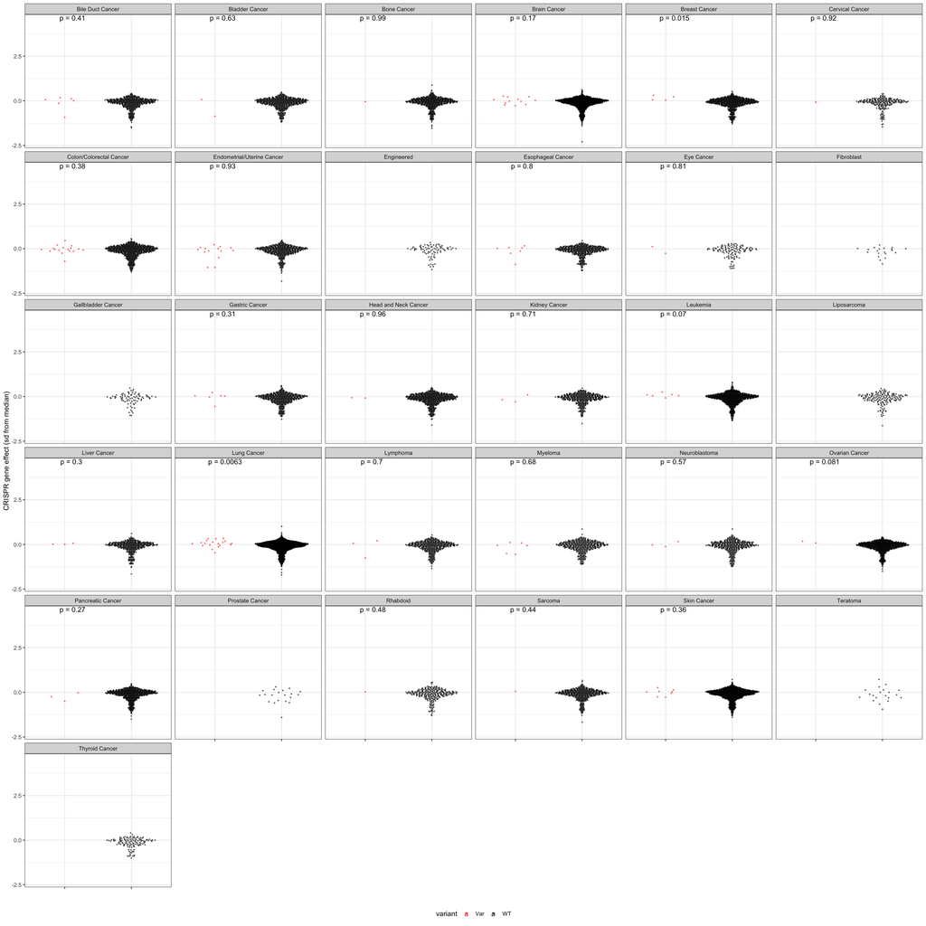

```r
df_crispr_splice_annot %>%
  filter(gene_deleterious == FALSE) %>%
  group_by(SYMBOL) %>%
  mutate(sum_splice_variants = sum(splice_variant)) %>%
  ungroup() %>%
  filter(sum_splice_variants > 3) %>%
  ggplot(aes(y = gene_effect, x = variant, color = variant)) +
  geom_quasirandom(alpha = 0.5, size = 0.5) +
  theme_bw() +
  facet_wrap("primary_disease") +
  scale_color_manual(values = c("red","black")) +
  xlab("") +
  ylab("CRISPR gene effect (sd from median)") +
  theme(axis.text.x = element_blank(),
        legend.position = "bottom") +
  stat_compare_means(label = "p.format", label.y = 4.5, label.x = 1)
```